# Midterm Final

Luis Sanchez Mercedes

11/22/2021

## I. Data Wranggling

I.I Extract the Data

```r
library(haven)
library(tidyverse)
library(caret)
```

```r
library(rpart)
library(ggplot2)
library(rattle)
library(gganimate)
library(gifski)
library(dplyr)
```

```r
# df_hhs <- read_sas('C:/Users/student/Downloads/hdd0318cy.sas7bdat')
# head(df_hhs)
```

I.II Filter the Data

```r
# df_hhs_y18 <- df_hhs %>%
               # filter(yod==18) %>%
               #  select( "yod", "payfix","pay_ub92","age",
               #    "sex","raceethn","provider","moa",
               #    "yoa","mod","admtype", "asource" ,
               #    "preopday" ,"los", "service" , "icu","ccu",
               #    "dispub92", "payer"  ,"drg","trandb",
               #   "randbg","randbs","orr", "anes","seq",
               #   "lab","dtest", "ther","blood","phar",
               #   "other","patcon","bwght","total","tot" ,
               #   "ecodub92","b_wt","pt_state","diag_adm","ancilar" ,
               #   "campus","er_fee","er_chrg","er_mode","obs_chrg",
               #   "obs_hour","psycchrg","nicu_day")
```

I.III Save File within current directory

```r
# write_csv(df_hhs_y18, 'midterm.csv')

df_hhs <- read_csv('midterm.csv')
head(df_hhs)
```

```
## # A tibble: 6 x 49
##     yod payfix pay_ub92   age   sex raceethn provider   moa   yoa   mod admtype
##   <dbl> <lgl>     <dbl> <dbl> <dbl>    <dbl>    <dbl> <dbl> <dbl> <dbl>   <dbl>
## 1    18 NA            9     0     1        1     7214     1    18     1       4
## 2    18 NA            2    76     2        1     7214     1    18     1       3
## 3    18 NA            6    50     2        1     7214    12    17     1       2
## 4    18 NA            4     0     1        7     7214     1    18     1       4
## 5    18 NA           13     0     1        1     7214    12    17     1       4
## 6    18 NA            4     0     2        9     7214    12    17     1       4
## # ... with 38 more variables: asource <chr>, preopday <dbl>, los <dbl>,
## #   service <chr>, icu <chr>, ccu <chr>, dispub92 <chr>, payer <chr>,
## #   drg <dbl>, trandb <chr>, randbg <chr>, randbs <chr>, orr <chr>, anes <chr>,
## #   seq <chr>, lab <chr>, dtest <chr>, ther <chr>, blood <chr>, phar <chr>,
## #   other <chr>, patcon <chr>, bwght <lgl>, total <chr>, tot <dbl>,
## #   ecodub92 <chr>, b_wt <chr>, pt_state <chr>, diag_adm <chr>, ancilar <chr>,
## #   campus <dbl>, er_fee <chr>, er_chrg <chr>, er_mode <dbl>, ...
```

I.IV Missing Variables

I.IV.I Fields with Missing

```r
colSums(is.na(df_hhs))
```

```
##      yod   payfix pay_ub92      age      sex raceethn provider      moa
##        0   131478        0        0        0     3950        0        0
##      yoa      mod  admtype  asource preopday      los  service      icu
##        0        0        1        6    60486        0        0        0
##      ccu dispub92    payer      drg   trandb   randbg   randbs      orr
##        0        0        0        0        0        0        0        0
##     anes      seq      lab    dtest     ther    blood     phar    other
##        0        0        0        0        0        0        0        0
##   patcon    bwght    total      tot ecodub92     b_wt pt_state diag_adm
##        0   131478        0        0   104339        0        3       50
##  ancilar   campus   er_fee  er_chrg  er_mode obs_chrg obs_hour psycchrg
##        0        0        0        0    12158        0    77343        0
## nicu_day
##   124090
```

I.IV.II Remove Fields

```r
df_hhs$payfix   <- NULL
df_hhs$preopday <- NULL
df_hhs$obs_hour <- NULL
df_hhs$nicu_day <- NULL
df_hhs$bwght    <- NULL
df_hhs$ecodub92 <- NULL
df_hhs$er_mode  <- NULL
df_hhs$diag_adm <- NULL

colSums(is.na(df_hhs))
```

```
##      yod pay_ub92      age      sex raceethn provider      moa      yoa
##        0        0        0        0     3950        0        0        0
##      mod  admtype  asource      los  service      icu      ccu dispub92
##        0        1        6        0        0        0        0        0
##    payer      drg   trandb   randbg   randbs      orr     anes      seq
##        0        0        0        0        0        0        0        0
##      lab    dtest     ther    blood     phar    other   patcon    total
##        0        0        0        0        0        0        0        0
##      tot     b_wt pt_state  ancilar   campus   er_fee  er_chrg obs_chrg
##        0        0        3        0        0        0        0        0
## psycchrg
##        0
```

I.V Admission & Discharge

I.V.I Fields

```r
head(df_hhs$moa) # Month of Admission
```

```
## [1]  1  1 12  1 12 12
```

```r
head(df_hhs$mod) # Month of Discharge
```

```
## [1] 1 1 1 1 1 1
```

I.V.II Admission by Month (Max)

```r
# October had the most admission
df_hhs %>%
  count(moa) %>%
    mutate(rank=rank(-n)) %>%
      filter(rank==1)
```

```
## # A tibble: 1 x 3
##     moa     n  rank
##   <dbl> <int> <dbl>
## 1    10 11408     1
```

I.V.III Admission by Month, Sex (Male)

```r
# October had the most male admission
df_hhs %>%
  filter(sex==1) %>%
   count(moa) %>%
    mutate(rank=rank(-n)) %>%
      filter(rank==1)
```

```
## # A tibble: 1 x 3
##     moa     n  rank
##   <dbl> <int> <dbl>
## 1    10  5164     1
```

I.V.IV Admission by Month, Sex (Female)

```r
# March had the most teenage female admission
df_hhs %>%
  filter(age<18, age>=12) %>%
   filter(sex==2) %>%
     count(moa) %>%
      mutate(rank=rank(-n)) %>%
       filter(rank==1)
```

```
## # A tibble: 1 x 3
##     moa     n  rank
##   <dbl> <int> <dbl>
## 1     3   172     1
```

I.V.V Admission by Month, Provider, Sex

```r
# Rhode Island Hospital had the most female admission in October
df_hhs %>%
  filter(moa==10) %>%
   filter(sex==2) %>%
    count(provider) %>%
      mutate(rank=rank(-n)) %>%
        filter(rank==1)
```

```
## # A tibble: 1 x 3
##   provider     n  rank
##      <dbl> <int> <dbl>
## 1     7205  1517     1
```

I.VI Age

I.VI.I Age by Sex

```r
# Male are typically older on average
df_hhs %>%
  filter(sex!=9) %>%
    group_by(sex) %>%
      summarize(avg = mean(age)) %>%
      arrange(-avg)
```

```
## # A tibble: 2 x 2
##     sex   avg
##   <dbl> <dbl>
## 1     1  51.5
## 2     2  50.9
```

I.VI.II Age by Months

```r
# January, June and December have the top 3 oldest patient
df_hhs %>%
  group_by(moa) %>%
   summarize(avg_age = mean(age)) %>%
   arrange(-avg_age)
```

```
## # A tibble: 12 x 2
##      moa avg_age
##    <dbl>   <dbl>
##  1     1    51.8
##  2     6    51.5
##  3    12    51.5
##  4     4    51.4
##  5     7    51.3
##  6     2    51.2
##  7     3    51.1
##  8    11    51.0
##  9     8    50.9
## 10    10    50.8
## 11     5    50.6
## 12     9    50.6
```

I.VII Charge

I.VII.I Charge by Provider

```r
# Women and Infants has the highest total charge
df_hhs %>%
   group_by(provider) %>%
    summarise(max = max(tot)) %>%
      mutate(rank=rank(-max)) %>%
        filter(rank==1)
```

```
## # A tibble: 1 x 3
##   provider     max  rank
##      <dbl>   <dbl> <dbl>
## 1     7214 3402056     1
```

I.VII.II Charge by Provider, Sex, Age

```r
# Rhode Island Hospital have the lowest charge to a teenage
df_hhs %>%
  filter(sex==1) %>%
   filter(age<18, age>=12) %>%
    group_by(provider) %>%
     summarize(min = min(tot)) %>%
      mutate(rank=rank(min)) %>%
       filter(rank==1)
```

```
## # A tibble: 1 x 3
##   provider   min  rank
##      <dbl> <dbl> <dbl>
## 1     7205  3272     1
```

I.VII Length of Stay

I.VII.I Create Variable

```r
spring <- c(3,4,5)
summer <- c(6,7,8)
fall   <- c(9,10,11)

df_hhs$season <- "Winter"
df_hhs$season[df_hhs$moa %in% spring] <- "Spring"
df_hhs$season[df_hhs$moa %in% summer] <- "Summer"
df_hhs$season[df_hhs$moa %in% fall]  <- "Fall"

table(df_hhs$season)
```

```
##
##   Fall Spring Summer Winter
##  32710  33651  32851  32266
```

I.VII.II Length of Stay by Season

```r
# Summer had the longest length of Stay with about 5 days
df_hhs %>%
  group_by(season) %>%
   summarise(avg=mean(los)) %>%
    arrange(-avg)
```

```
## # A tibble: 4 x 2
##   season   avg
##   <chr>  <dbl>
## 1 Summer  4.96
## 2 Fall    4.96
## 3 Winter  4.93
## 4 Spring  4.84
```

I.VI.III Length of Stay by Age, Sex

```r
# 20-year old male patient stayed a day for the fall season has to on average pay $16k
df_hhs %>%
  filter(sex==1) %>%
   filter(age==20) %>%
    filter(season=="Fall") %>%
     filter(los==1) %>%
        summarise(avg=mean(tot))
```

```
## # A tibble: 1 x 1
##     avg
##   <dbl>
## 1 16511
```

In summary, here is a brief description of the insights extracted from this section. In terms of missing values, the variable of payfix, preorday, observation hours, number of icu days, birth weight, and ecodub92 were removed due to its high concentration of missing. In terms of month of admission, the month of October had the highest number of admissions and consequently, the most male patients admitted. The month of march had the most teenage female admitted. Rhode Island Hospital had the most female admission in October. January had the oldest patients by average with an age of 51.8. Women and Infants hold the highest charge of any provider with a 3 million charge. Rhode Island Hospital had the least total charge for a teenage boy with a value of approximately 3k. In terms of season, the length of stay was distributed by Summer 4.96, Fall 4.96, Winter 4.93, Spring 4.84. Summer had the longest. Finally on average a 20-year old male staying one day gets charged approximately 16k. Overall, pretty interesting data. The one that struck me the most was the statistics of the 20-year old male since as someone close to that age, it was surprising the average cost was that high.

## II. Data Visualization

II.I Illustration of Study

```r
# Modify race variable to include this information
df_hhs$race <- "None"
df_hhs$race[df_hhs$raceethn==1] <- "White"
df_hhs$race[df_hhs$raceethn==2] <- "Black"
df_hhs$race[df_hhs$raceethn==3] <- "Asian"
df_hhs$race[df_hhs$raceethn==7] <- "Hispanic"
df_hhs$race[df_hhs$raceethn %in% c(4, 5, 6, 9)] <- "Other"

table(df_hhs$race)
```

```
##
##    Asian    Black Hispanic     None    Other    White
##     1688     8721    15853     3950     3954    97312
```

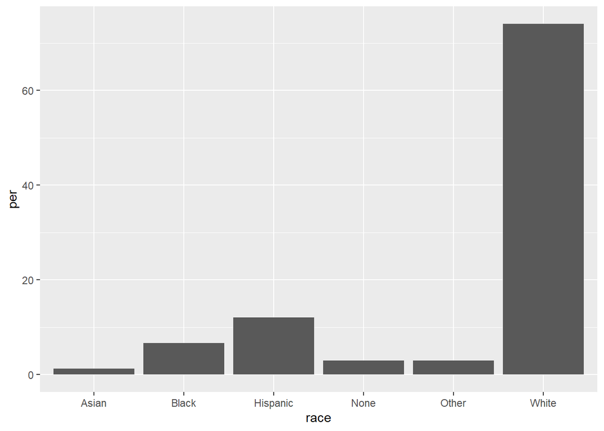

```r
# Percentage of Patients by Race,
df_hhs %>%
  group_by(race) %>%
    count() %>% ungroup %>%
    mutate(per = 100*n/sum(n)) %>%
    ggplot(mapping = aes(x=race, y=per)) +
     geom_col() +
     annotate("text", label='Hello World')
```

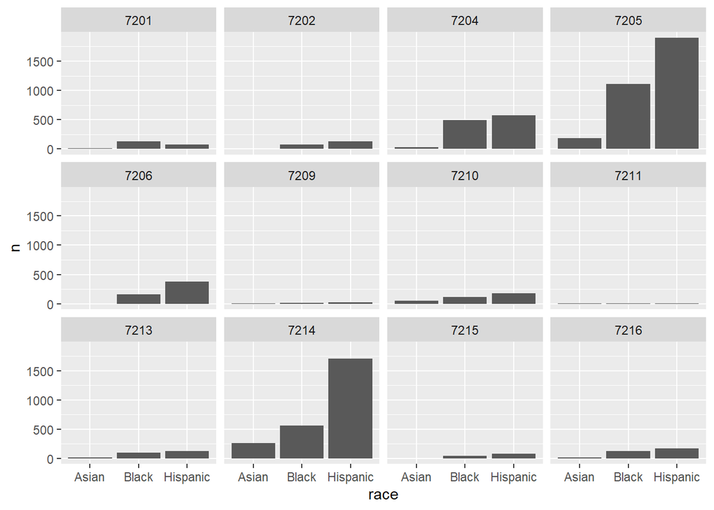

```r
# Number of Color Patients by Provider
df_hhs$provider <- factor(df_hhs$provider)
of_color <- c("Black", "Asian", "Hispanic")

df_hhs %>%
  filter(race==of_color) %>%
  group_by(provider, race) %>%
   count() %>%
   ggplot(mapping=aes(x=race, y=n)) +
    geom_col() +
    facet_wrap(~provider)
```

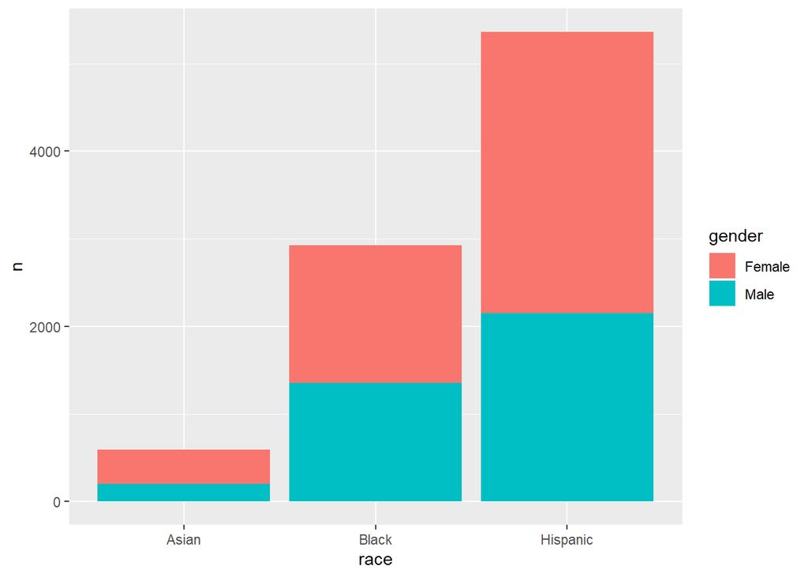

```r
# Number of Color Patients by Sex
df_hhs$gender <-  "None"
df_hhs$gender[df_hhs$sex==1] <- "Male"
df_hhs$gender[df_hhs$sex==2] <- "Female"


df_hhs %>%
  filter(race==of_color) %>%
  filter(sex!="None") %>%
   group_by(race, gender) %>%
   count() %>%
   ggplot(mapping = aes(x=race, y=n, fill=gender)) +
    geom_col()
```

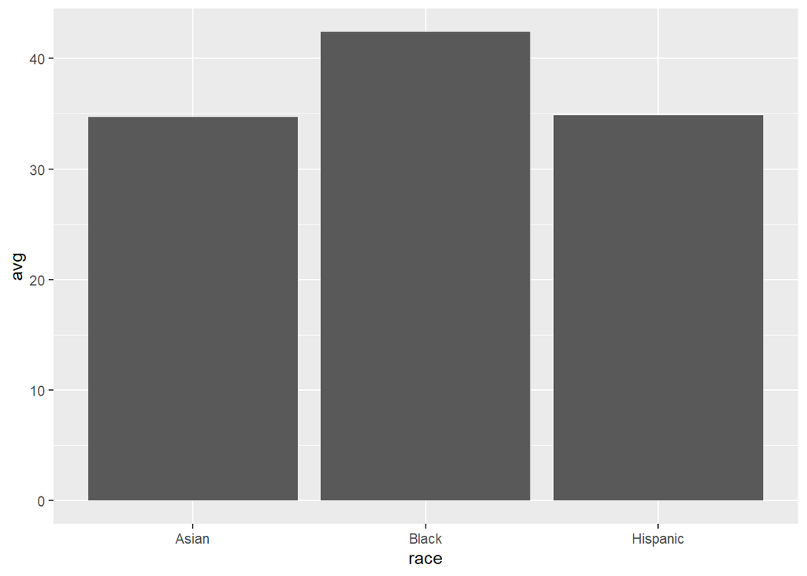

```r
# Average Age for Of-Color Patients
df_hhs %>%
  filter(race==of_color) %>%
   group_by(race) %>%
   summarise(avg = mean(age)) %>%
    ggplot(mapping=aes(x=race, y=avg)) +
     geom_col()
```

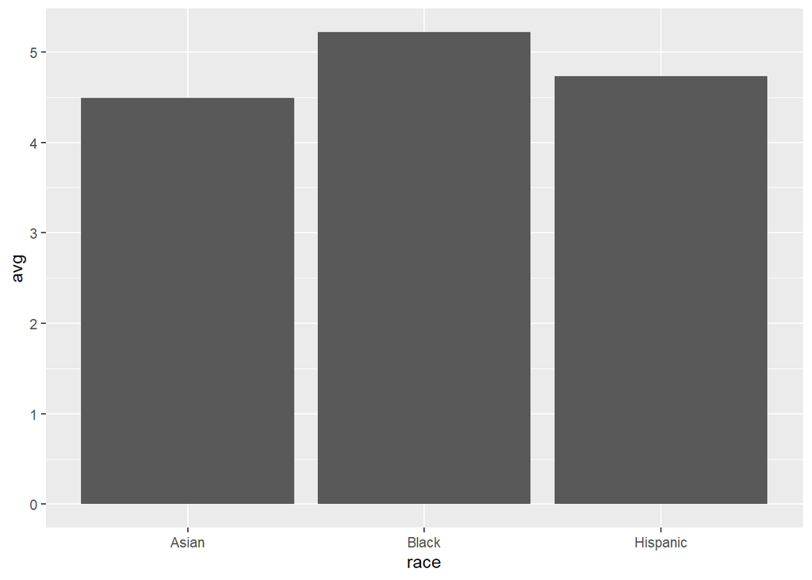

```r
# Average Length of Stay for Of-Color Patients
df_hhs %>%
  filter(race==of_color) %>%
   group_by(race) %>%
   summarise(avg = mean(los)) %>%
    ggplot(mapping=aes(x=race, y=avg)) +
     geom_col()
```

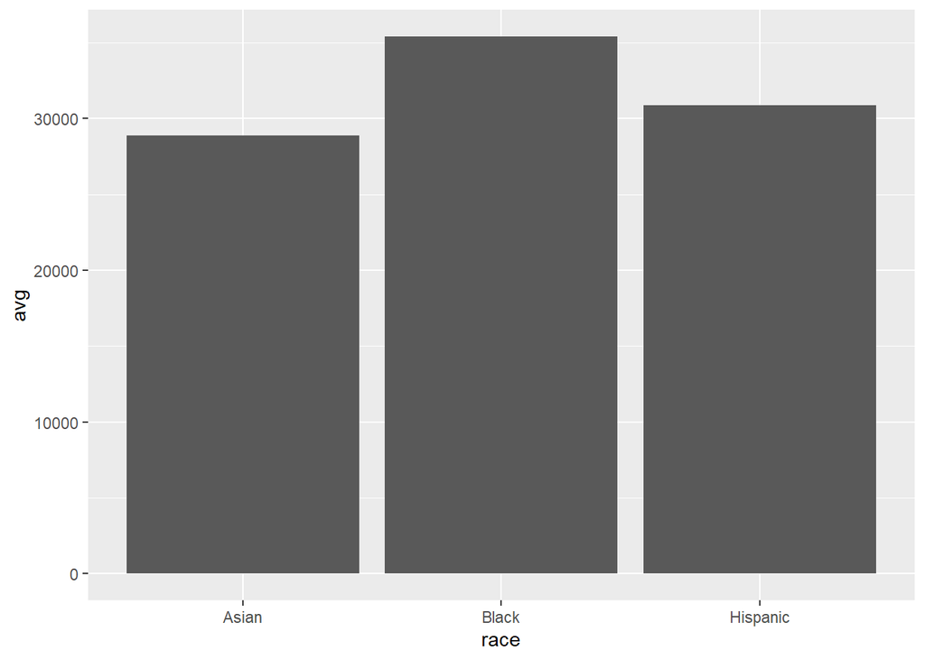

```r
# Average Total Pay for Of-Color Patients
df_hhs %>%
  filter(race==of_color) %>%
   group_by(race) %>%
   summarise(avg = mean(tot)) %>%
    ggplot(mapping=aes(x=race, y=avg)) +
     geom_col()
```

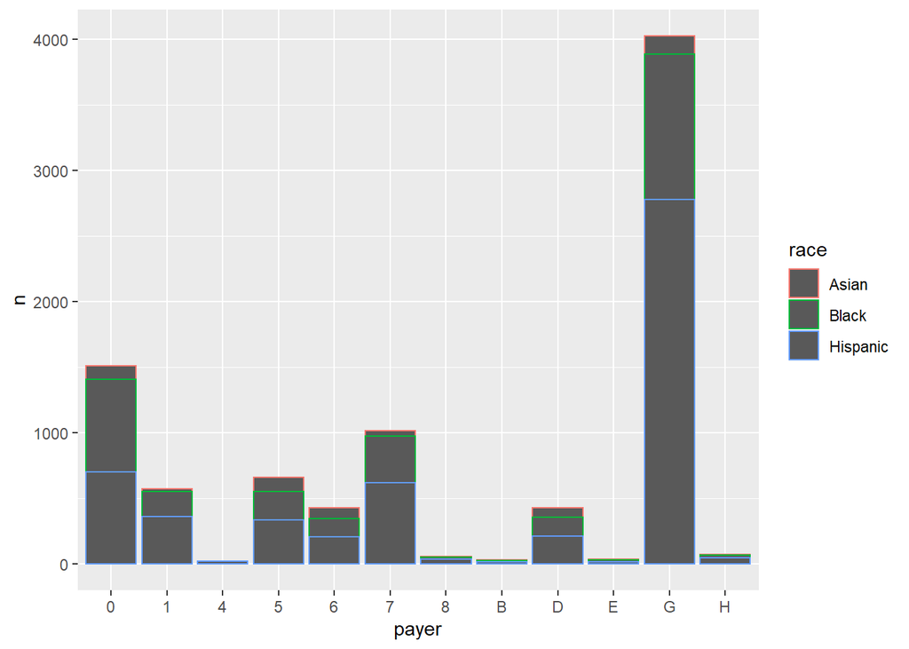

```r
# Payer Type by Of-Color Patients
df_hhs %>%
  filter(race==of_color) %>%
   group_by(payer, race) %>%
   count() %>%
    ggplot(mapping=aes(x=payer, y=n, color=race)) +
     geom_col()
```

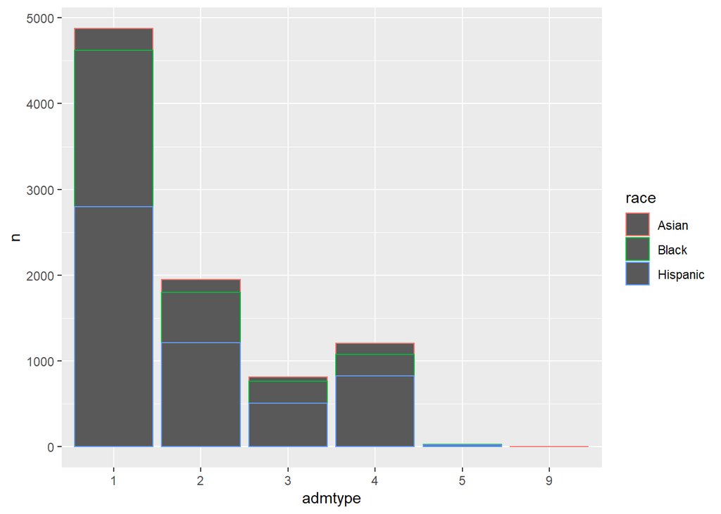

```r
# Admission Type by Of-Color Patient
df_hhs$admtype <- factor(df_hhs$admtype)

df_hhs %>%
  filter(race==of_color) %>%
   group_by(admtype, race) %>%
   count() %>%
    ggplot(mapping=aes(x=admtype, y=n, color=race)) +
     geom_col()
```

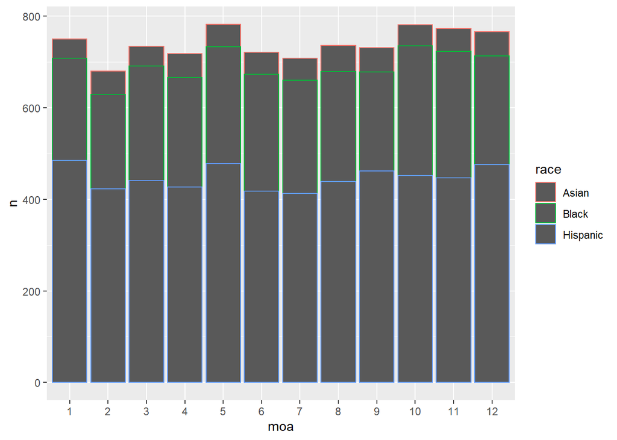

```r
# Number of Patients by Month
df_hhs$moa <- factor(df_hhs$moa)

df_hhs %>%
  filter(race==of_color) %>%
   group_by(moa, race) %>%
   count() %>%
    ggplot(mapping=aes(x=moa, y=n, color=race)) +
     geom_col()
```

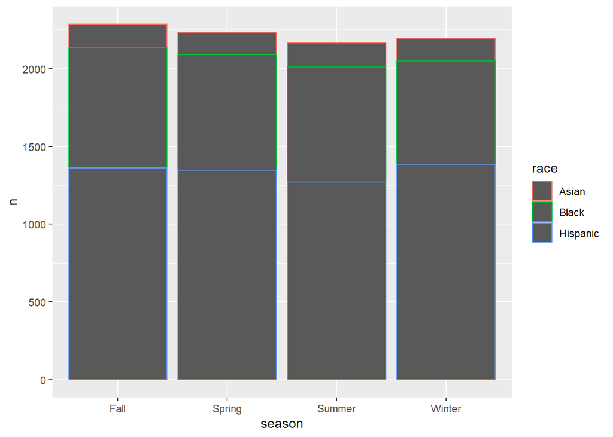

```r
# Number of Patients by Season
df_hhs$moa <- as.numeric(df_hhs$moa)

spring <- c(3,4,5)
summer <- c(6,7,8)
fall   <- c(9,10,11)

df_hhs$season <- "Winter"
df_hhs$season[df_hhs$moa %in% spring] <- "Spring"
df_hhs$season[df_hhs$moa %in% summer] <- "Summer"
df_hhs$season[df_hhs$moa %in% fall]  <- "Fall"

df_hhs %>%
  filter(race==of_color) %>%
   group_by(season, race) %>%
   count() %>%
    ggplot(mapping=aes(x=season, y=n, color=race)) +
     geom_col()
```

[figure not shown]

```r
# Total Pay by Month
df_hhs %>%
  filter(race==of_color) %>%
   group_by(moa, race) %>%
   summarise(avg = mean(tot)) %>%
    ggplot(aes(x=moa, y=avg, color=race)) +
     geom_line() +
     transition_reveal(moa)
```

## III. Predictive Modeling

III.I Designing Data Set

III.I.I Target Variable

```r
median <- median(df_hhs$tot)

df_hhs$target <- 'low'
df_hhs$target[df_hhs$tot>=median] <- 'high'

table(df_hhs$target)
```

```
##
##  high   low
## 65743 65735
```

III.I.II Create Dataset

```r
df_hhs_x <- df_hhs %>%
              select(age,sex,raceethn,provider,moa,mod,admtype,campus,los,target) %>%
                filter(raceethn!='') %>%
                 filter(admtype!='')

df_hhs_x$sex <- factor(df_hhs_x$sex)
df_hhs_x$raceethn <- factor(df_hhs_x$raceethn)
df_hhs_x$provider <- factor(df_hhs_x$provider)
df_hhs_x$moa <- factor(df_hhs_x$moa)
df_hhs_x$mod <- factor(df_hhs_x$mod)
df_hhs_x$admtype <- factor(df_hhs_x$admtype)
df_hhs_x$campus <- factor(df_hhs_x$campus)
```

III.I.III Split Dataset

```r
set.seed(2020)
splitIndex <- createDataPartition(df_hhs_x$target, p=.90, list=FALSE)

df_train <- df_hhs_x[splitIndex, ]
df_test  <- df_hhs_x[-splitIndex,]
head(df_train)
```

```
## # A tibble: 6 x 10
##     age sex   raceethn provider moa   mod   admtype campus   los target
##   <dbl> <fct> <fct>    <fct>    <fct> <fct> <fct>   <fct>  <dbl> <chr>
## 1     0 1     1        7214     1     1     4       0          2 low
## 2    76 2     1        7214     1     1     3       0          1 high
## 3    50 2     1        7214     12    1     2       0          3 high
## 4     0 1     1        7214     12    1     4       0         35 high
## 5     0 2     9        7214     12    1     4       0         17 high
## 6     0 2     1        7214     1     1     4       0          2 low
```

III.II Model: Decision Tree

III.II.I Design of Model and Prediction

```r
decision_tree <- rpart(target~., data=df_train, control=rpart.control(maxdepth=3))
prediction <- predict(decision_tree, df_test, type='class')
```

III.II.II Design of Tree

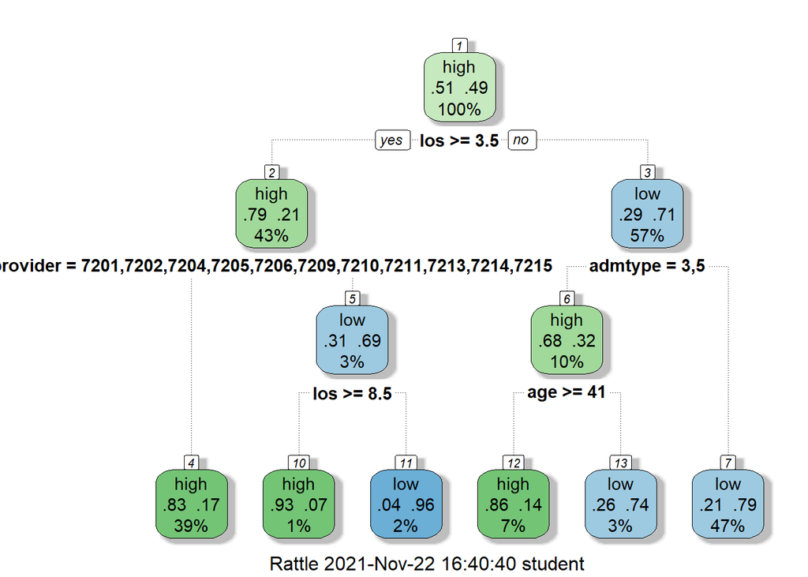

```r
fancyRpartPlot(decision_tree)
```

III.II.III Variable Importance

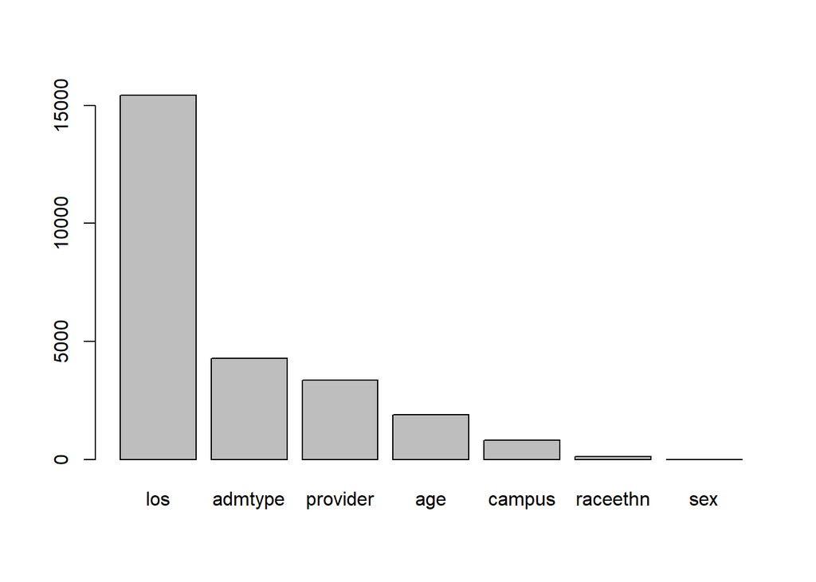

```r
barplot(decision_tree$variable.importance)
```

III.III Model: Logistic Regression

III.III.I Design Model

```r
# tuneGrid = expand.grid(iter = 1:3)
# trControl = trainControl(method = "cv", number = 5)
#
# logistic <- train(target~.,data = df_train,
#                       method = "LMT",
#                       trControl = trControl,
#                       tuneGrid = tuneGrid)
```

III.III.II Hyperparameters

```r
# plot(logistic)
```

III.IV Model: Random Forest

III.IV.I Design Model

```r
# tuneGrid = expand.grid(mtry = 2:3)
# trControl = trainControl(method = "cv", number = 2)
#
# random_forest <- train(target~.,data = df_train,
#                                 method = "rf",
#                                 trControl = trControl,
#                                 tuneGrid = tuneGrid)
```

III.IV.II Hyperparameters

```r
# plot(random_forest)
```

III.V Model: Naive Bayes Classifier

III.V.I Design Model

```r
# tuneGrid = expand.grid(smooth=1:3)
# trControl = trainControl(method = "cv", number = 5)
#
# bayes <- train(target~.,data = df_train,
#                            method = "nbDiscrete",
#                            trControl = trControl,
#                            tuneGrid = tuneGrid)
```

III.V.II Hyperparameters

```r
# plot(bayes)
```

```r
# results <- resamples(list('Decision Tree' = decision_tree,
#                           'Random Forest' = random_forest,
#                           'Logistic' = logistic,
#                           'Naive Bayes'= bayes))
# bwplot(results)
```

III.VI Personalized Model

```r
df_hhs_x$target <- "Not_OfColor"
df_hhs_x$target[df_hhs_x$raceethn %in% c("2", "3", "7")] <- "OfColor"

df_hhs_x$raceethn <- NULL

table(df_hhs_x$target)
```

```
##
## Not_OfColor     OfColor
##      101265       26262
```

Split Dataset

```r
set.seed(2020)
splitIndex <- createDataPartition(df_hhs_x$target, p=.90, list=FALSE)

df_train <- df_hhs_x[splitIndex, ]
df_test  <- df_hhs_x[-splitIndex,]
head(df_train)
```

```
## # A tibble: 6 x 9
##     age sex   provider moa   mod   admtype campus   los target
##   <dbl> <fct> <fct>    <fct> <fct> <fct>   <fct>  <dbl> <chr>
## 1     0 1     7214     1     1     4       0          2 Not_OfColor
## 2    76 2     7214     1     1     3       0          1 Not_OfColor
## 3    50 2     7214     12    1     2       0          3 Not_OfColor
## 4     0 1     7214     1     1     4       0          4 OfColor
## 5     0 1     7214     12    1     4       0         35 Not_OfColor
## 6     0 2     7214     12    1     4       0         17 Not_OfColor
```

III.II Model: Decision Tree

III.II.I Design of Model and Prediction

```r
# decision_tree2 <- rpart(target~., data=df_train, control=rpart.control(maxdepth=3))
# prediction <- predict(decision_tree2, df_test, type='class')
# decision_tree2
```

III.II.II Design of Tree

```r
# fancyRpartPlot(decision_tree2)
```

III.II.III Variable Importance

```r
# barplot(decision_tree$variable.importance)
```

Design Model

```r
# tuneGrid = expand.grid(iter = 1:2)
# trControl = trainControl(method = "cv", number = 5)
#
# logistic2 <- train(target2~.,data = df_train,
#                       method = "LMT",
#                       trControl = trControl,
#                       tuneGrid = tuneGrid)
```

Hyperparameters

```r
# plot(logistic2)
```

Design Model

```r
# tuneGrid = expand.grid(mtry = 2:4)
# trControl = trainControl(method = "cv", number = 5)
#
# random_forest2 <- train(target2~.,data = df_train,
#                                 method = "rf",
#                                 trControl = trControl,
#                                 tuneGrid = tuneGrid)
```

Hyperparameters

```r
# plot(random_forest2)
```

Design Model

```r
# tuneGrid = expand.grid(smooth=1:3)
# trControl = trainControl(method = "cv", number = 5)
#
# bayes2 <- train(target2~.,data = df_train,
#                           method = "nbDiscrete",
#                           trControl = trControl,
#                           tuneGrid = tuneGrid)
```

III.V.II Hyperparameters

```r
# plot(bayes2)
```

```r
# results <- resamples(list('Decision Tree' = decision_tree2,
#                           'Random Forest' = random_forest2,
#                           'Logistic' = logistic2,
#                           'Naive Bayes'= bayes2))
#
# bwplot(results)
```